# Research Ethics

Adam La Caze

Semester 1, 2022

## Objectives

- Understand the key values that underpin research ethics
- Understand the structure and process for ethical review of human research in Australia
- Appreciate some of the challenging ethical issues that arise from human research

## Key concepts

- Much of the regulation surrounding clinical research is a response to bad things done in the name of research
- Clinical research needs to be good science, respect participants, and fair.
- Human Research Ethics Committees, a committee of researchers, health professionals and community representatives, review and approve clinical research against the National Statement
- Clinical research poses interesting and often difficult ethical questions.

# Introduction

## History

A brief history of bad things done in the name of research and some key responses

| 1932 | [Tuskegee](http://en.wikipedia.org/wiki/Tuskegee_syphilis_experiment) starts |
| --- | --- |
| 1941–5 | [Nazi medical trials](http://en.wikipedia.org/wiki/Nazi_human_experimentation) |
| 1947 | [Nuremberg Code](http://en.wikipedia.org/wiki/Nuremberg_Code) |
| 1964 | [Declaration of Helsinki](http://en.wikipedia.org/wiki/Declaration_of_Helsinki) |
| 1972 | Tuskegee is terminated |
| 1999 | [Alder Hey organ retention scandal](http://en.wikipedia.org/wiki/Alder_Hey_organs_scandal) |

## [The Tuskegee Study](http://en.wikipedia.org/wiki/Tuskegee_syphilis_experiment)

- A forty-year study on the natural history of syphilis conducted by the US Public Health Service from 1932–1972.
- In 1932 the therapies used for syphilis were ineffective and toxic.
- By 1947 penicillin was available and being used effectively across the US, but study researchers prevented subjects from receiving treatment.
- In 1966 the study was still being supported by the Center for Disease Control and local chapters of the American Medical Association.
- The study is terminated following media reports and a public outcry in 1972.

## Key principles in bioethics

- Respect for Autonomy: *respect the rights and dignity of individuals*
- Beneficence: *help people*
- Non-maleficence: *do no harm*
- Justice: *treat people fairly*

## Key principles in research ethics

- **Merit and integrity of the research**: *conduct good studies well*
- Respect for Autonomy: *respect the rights and dignity of individuals*
- Beneficence: *help people*
- Non-maleficence: *do no harm*
- Justice: *treat people fairly*

# The ethical review process

## Process

- The Declaration of Helsinki has been incorporated into local law and practice in most countries
- Central to the system is a committee composed of experts and community representatives, these are called [Institutional Review Boards](http://en.wikipedia.org/wiki/Institutional_review_board) (IRBs) in the US and Human Research Ethics Committees (HRECs) here
- All human research needs ethical review. All human research that has the potential to cause anything more than minor discomfort needs to be reviewed by a HREC

## Human Research Ethics Committees

- Minimum of 8 people, ideally equal men and women with a third of the committee external to the institution
- At least:
  - Two lay people
  - One health care professional
  - One person who performs a pastoral role (e.g. priest or Aboriginal elder)
  - One lawyer
  - Two researchers

(National Statement, 81–1)

# Key principles in research ethics

## Merit and integrity

- Research has to be good science to be ethical. Research with merit
  - aims to fill gaps in our knowledge
  - is well designed to answer its aims
- Integrity refers to the way that the research is conducted. There is a genuine search for knowledge and understanding, the research is conducted honestly, and the results are distributed regardless of outcome

## Beneficence/non-maleficence

- The potential benefits of research need to outweigh the risks
- The benefits of the research may accrue to people other than those involved in the study
- The risks involved in some studies is great, what is important is that the risks are considered, minimised and **clearly explained**

## Respect

- Respect people involved in research, including: their welfare, beliefs, cultural heritage, perceptions and customs
- Respect the capacity people have to make their own decisions about participation
- Respect people unable to make their own decisions, empower them to be as involved as possible and protect them by involving people who can advocate on their behalf

## Informed consent

- Participation in research is **voluntary**. Due respect for participants requires **informed consent**.
- People need to be given enough information about the study to be able to decide whether to participate.
  - What does participation involve? What are the risks of participation? What are the alternatives to participation? What will happen to my information?
- The effect of unequal power in relationships should be considered.
- The need for informed consent may be waived in specific circumstances
  - Low risk *and* benefits outweigh harm of not seeking consent *and* impractical to obtain consent *and* there is no reason for thinking the participant would refuse *and* there is sufficient protection of privacy, …

## Types of consent

- ‘Specific’ to a particular project
- ‘Extended’ to future projects that are an extension of the present project or very similar
- ‘Unspecified’ data and/or tissue (usually de-identified) may be used in any future research

## Justice

- Are the inclusion and exclusion criteria for the study fair given the objectives of the research? (Unfair **exclusion** is more common than unfair inclusion)
- Are the burdens on participation on particular groups reasonable?
- Is there fair access to the benefits of research?

# Cases and additional considerations

## Early ECMO studies

- Bartlett et al. (1982) reported a case series that included 45 newborns judged to have less than 10% chance of survival; these infants we treated with ECMO and 25/45 survived
- Bartlett et al. (1985) was designed to prove ECMO was effective in these patients.
  - The study enrolled infants judged to have $\ge$ 80% mortality rate. Only infants receiving ECMO provided informed consent.
  - Randomised-play-the-winner design; more infants were to be recruited to whichever treatment arm was the more successful. Planned to stop after 10 survivors or 10 deaths.
  - Overall 1 control patient (who died) and 11 ECMO patients (who survived). A further 8 patients were given ECMO and survived.

## Some considerations that arise from Bartlett et al. (1985)

- The importance of research on vulnerable populations
- The importance of informed consent. Do you think it was appropriate that only parents of infants that received ECMO gave informed consent to participate?
- What standard should be used by clinicians to decide whether or not they should enrol their patient in research?

## The Uncertainty Principle/Personal Care Principle/Clinical Equipoise

**Uncertainty Principle**

randomization is acceptable when the clinician-investigator is uncertain which of the randomized treatments is best for the patient (Peto & Biagent, 1998; Pocock, 1993)

**Personal Care Principle**

randomization is acceptable when the clinician-investigator is indifferent between the randomized treatments for the patient (Royall, 2008)

**‘Clinical Equipoise’**

randomization is acceptable when there is no consensus within the clinical community as to which of the randomized treatments is best for the patient (or group of patients) (Freedman, 1987)

## Antidepressants in children and adolescents

- Depression in children and adolescents is common
- Treatment with SSRIs and other antidepressants has been relatively common
- **But** only very limited research has been conducted on the use of antidepressants in children and adolescents. There is considerable controversy about both efficacy and safety.
- Which principle of research ethics does this situation violate?

## Developing new oncology treatments

Developing new oncology treatments

- First use in humans is typically on cancer patients with poor prognosis, e.g. expected survival without treatment may be 3 months and best-case survival on treatment up to 5 months
- The new treatments carry significant risks, not all of them known and the studies may include a range of additional invasive procedures
- In a randomized study treatment or control is decided by chance.

## Phase I trial of imatinib in chronic myeloid leukaemia (Druker et al., 2001)

- Dose escalation trial in chronic phase CML patients in whom interferon-$\alpha$ treatment had failed. Prognosis is poor, life expectancy measured in months.
- 83 patients successively assigned to 1 of 14 dose cohorts, ranging from 25mg–1000mg per day
- 53 of the 54 patients on $\ge$ 300mg/day had a complete haematological response (reduced WBC and platelet count maintained for four weeks). 51 of these patients maintained this response up to 265 days.

## Who owns trial data?

The standard view has been that trial data is owned by whomever conducted the study. That view is changing.

More publishers are stipulating that data is made available following clinical trials of medicines and devices, see for example Godlee & Groves (2012).

## Oseltamivir (Tamiflu)

- Oseltamivir is approved for use in influenza and is recommended by the World Health Organisation, the US Centers for Disease Control and Prevention, and many more
- It is recommended (and stockpiled) in many countries **based on the belief that oseltamivir reduces complication associated with influenza**
- Despite this many of the Phase III trials conducted with oseltamivir remain unpublished
- The BMJ held a public campaign to improve access to data on oseltamivir: http://www.bmj.com/tamiflu

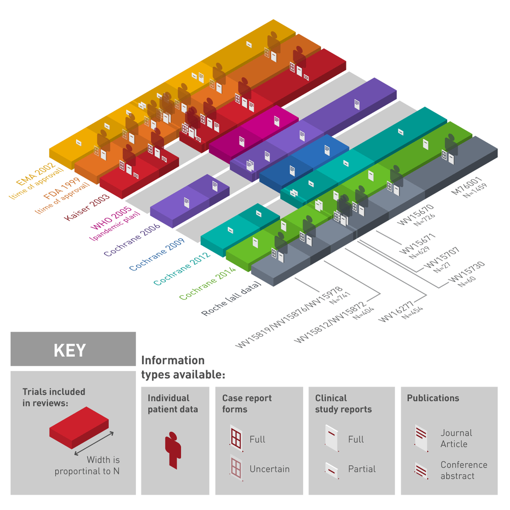

Oseltamivir data and published reports: [source](http://www.bmj.com/tamiflu)

- Jefferson et al. (2014) provides a rigourous meta-analysis of oseltamivir data (full clinical trial reports, case reports, etc)
- Benefits of oseltamivir on influenza are modest: shorter time to first alleviation of symptoms (16.8 hours, 95% confidence interval 8.4–25.1)
- Limited compelling data on complications (e.g. pneumonia, hospitalisation and death)

Bartlett, R. H., Andrews, A. F., Toomasian, J. M., Haiduc, N. J., & Gazzaniga, A. B. (1982). Extracorporeal membrane oxygenation for newborn respiratory failure: forty-five cases. *Surgery*, *92*(2), 425–433.

Bartlett, R. H., Roloff, D. W., Cornell, R. G., Andrews, A. F., Dillon, P. W., Zwischenberger, J. B., Ware, J. H., & Epstein, M. F. (1985). Extracorporeal circulation in neonatal respiratory failure: a prospective randomized study. *Pediatrics*, *76*(4), 479–487.

Druker, B. J., Talpaz, M., Resta, D. J., & Al, E. (2001). Efficacy and safety of a specific inhibitor of the BCR-ABL tyrosine kinase in chronic myeloid leukemia. *The New England Journal of Medicine*, *344*(14), 1031–1037.

Freedman, B. (1987). Equipoise and the ethics of clinical research. *The New England Journal of Medicine*, *317*(3), 141–145.

Godlee, F., & Groves, T. (2012). The new BMJ policy on sharing data from drug and device trials. *BMJ (Clinical Research Ed)*, *345*(nov20 3), e7888–e7888. https://doi.org/10.1136/bmj.e7888

Jefferson, T., Jones, M., Doshi, P., Spencer, E. A., Onakpoya, I., & Heneghan, C. J. (2014). Oseltamivir for influenza in adults and children: systematic review of clinical study reports and summary of regulatory comments. *BMJ (Clinical Research Ed)*, *348*(apr09 2), g2545–g2545. https://doi.org/10.1136/bmj.g2545

Peto, R., & Biagent, C. (1998). Trials: The next 50 years. Large scale randomised evidence of moderate benefits. *British Medical Journal*, *317*(7167), 1170–1171.

Pocock, S. J. (1993). Statistical and ethical issues in monitoring clinical trials. *Statistics in Medicine*, *12*(15-16), 1455–1459. http://www.ncbi.nlm.nih.gov/sites/entrez?Db=pubmed&Cmd=Retrieve&list_uids=8248657&dopt=abstractplus

Royall, R. M. (2008). Ethics and statistics in randomized clinical trials. *Statistical Science*, *6*(1), 52–62.